# Multi-Class Model for Fetal Health Classification Using Python and TensorFlow

### February 24, 2022

Template Credit: Adapted from a template made available by Dr. Jason Brownlee of Machine Learning Mastery. [https://machinelearningmastery.com/]

SUMMARY: The project aims to construct a predictive model using various machine learning algorithms and document the end-to-end steps using a template. The Fetal Health Classification dataset is a multi-class modeling situation where we are trying to predict one of several (more than two) possible outcomes.

INTRODUCTION: This dataset contains 2,126 records of features extracted from Cardiotocography exams. Cardiotocograms are a simple and cost accessible option to assess fetal health. The equipment works by sending ultrasound pulses and reading its response, thus highlighting fetal heart rate, fetal movements, uterine contractions, and more. Three expert obstetricians classified the outcomes into three classes: Normal, Suspect, and Pathological.

ANALYSIS: The average performance of the preliminary TensorFlow models achieved an accuracy benchmark of 92.03%. When we processed the test dataset with the final model, the model achieved an accuracy score of 91.84%.

CONCLUSION: In this iteration, TensorFlow appeared to be a suitable algorithm for modeling this dataset.

Dataset Used: Fetal Health Classification Dataset

Dataset ML Model: Multi-Class classification with numerical features

Dataset Reference: https://www.kaggle.com/andrewmvd/fetal-health-classification

One source of potential performance benchmarks: https://www.kaggle.com/andrewmvd/fetal-health-classification/code

## Task 1 - Prepare Environment

```python
# Retrieve the GPU information
gpu_info = !nvidia-smi
gpu_info = '\n'.join(gpu_info)
if gpu_info.find('failed') >= 0:
    print('Select the Runtime → "Change runtime type" menu to enable a GPU accelerator, ')
    print('and then re-execute this cell.')
else:
    print(gpu_info)
```

```
Sat Feb 19 19:11:35 2022
+-----------------------------------------------------------------------------+
| NVIDIA-SMI 450.36.06    Driver Version: 450.36.06    CUDA Version: 11.4     |
|-------------------------------+----------------------+----------------------+
| GPU  Name        Persistence-M| Bus-Id        Disp.A | Volatile Uncorr. ECC |
| Fan  Temp  Perf  Pwr:Usage/Cap|         Memory-Usage | GPU-Util  Compute M. |
|                               |                      |               MIG M. |
|===============================+======================+======================|
|   0  Quadro RTX 4000     On   | 00000000:00:05.0 Off |                  N/A |
| 30%   32C    P5    15W / 125W |      1MiB /  7982MiB |      0%      Default |
|                               |                      |                  N/A |
+-------------------------------+----------------------+----------------------+

+-----------------------------------------------------------------------------+
| Processes:                                                                  |
|  GPU   GI   CI        PID   Type   Process name                  GPU Memory |
|        ID   ID                                                   Usage      |
|=============================================================================|
|  No running processes found                                                 |
+-----------------------------------------------------------------------------+
```

```python
# Retrieve the memory configuration
from psutil import virtual_memory
ram_gb = virtual_memory().total / 1e9
print('Your runtime has {:.1f} gigabytes of available RAM\n'.format(ram_gb))

if ram_gb < 20:
    print('To enable a high-RAM runtime, select the Runtime → "Change runtime type"')
    print('menu, and then select High-RAM in the Runtime shape dropdown. Then, ')
    print('re-execute this cell.')
else:
    print('You are using a high-RAM runtime!')
```

```
Your runtime has 31.6 gigabytes of available RAM

You are using a high-RAM runtime!
```

```python
# Retrieve the CPU information
ncpu = !nproc
print("The number of available CPUs is:", ncpu[0])
```

```
The number of available CPUs is: 8
```

### 1.a) Load libraries and modules

```python
# Set the random seed number for reproducible results
RNG_SEED = 888
```

```python
import random
random.seed(RNG_SEED)
import numpy as np
np.random.seed(RNG_SEED)
import pandas as pd
import seaborn as sns
import matplotlib.pyplot as plt
import os
import sys
import math
# import boto3
from datetime import datetime
from sklearn import preprocessing
from sklearn.model_selection import train_test_split
from sklearn.model_selection import RepeatedKFold
from sklearn.model_selection import cross_val_score
from sklearn.metrics import classification_report
from sklearn.metrics import confusion_matrix
from sklearn.metrics import accuracy_score
from sklearn.pipeline import Pipeline
from sklearn import compose
from sklearn import impute

# from sklearn.feature_selection import RFE
# from imblearn.pipeline import Pipeline
# from imblearn.over_sampling import SMOTE
# from imblearn.under_sampling import RandomUnderSampler

import tensorflow as tf
tf.random.set_seed(RNG_SEED)
from tensorflow import keras
from tensorflow.keras.callbacks import ReduceLROnPlateau
```

### 1.b) Set up the controlling parameters and functions

```python
# Begin the timer for the script processing
START_TIME_SCRIPT = datetime.now()
```

```python
# Set up the number of CPU cores available for multi-thread processing
N_JOBS = 1

# Set up the flag to stop sending progress emails (setting to True will send status emails!)
NOTIFY_STATUS = False

# Set the percentage sizes for splitting the dataset
TEST_SET_RATIO = 0.15
VAL_SET_RATIO = 0.15

# Set the number of folds for cross validation
N_FOLDS = 5
N_ITERATIONS = 1

# Set various default modeling parameters
DEFAULT_LOSS = 'categorical_crossentropy'
DEFAULT_METRICS = ['accuracy']
DEFAULT_OPTIMIZER = tf.keras.optimizers.Adam(learning_rate=0.0005)
CLASSIFIER_ACTIVATION = 'softmax'
MAX_EPOCHS = 50
BATCH_SIZE = 32
NUM_CLASSES = 3

# Define the labels to use for graphing the data
TRAIN_METRIC = "accuracy"
VALIDATION_METRIC = "val_accuracy"
TRAIN_LOSS = "loss"
VALIDATION_LOSS = "val_loss"

# Define the directory locations and file names
TRAIN_DATASET = 'fetal_health.csv'
# TEST_DATASET = ''

# Check the number of GPUs accessible through TensorFlow
print('Num GPUs Available:', len(tf.config.list_physical_devices('GPU')))

# Print out the TensorFlow version for confirmation
print('TensorFlow version:', tf.__version__)
```

```
Num GPUs Available: 1
TensorFlow version: 2.6.0
```

```
2022-02-19 19:11:38.167338: I tensorflow/stream_executor/cuda/cuda_gpu_executor.cc:1050] successful NUMA node read from SysFS had negative value (-1), but there must be at least one NUMA node, so returning NUMA node zero
2022-02-19 19:11:38.179914: I tensorflow/stream_executor/cuda/cuda_gpu_executor.cc:1050] successful NUMA node read from SysFS had negative value (-1), but there must be at least one NUMA node, so returning NUMA node zero
2022-02-19 19:11:38.180589: I tensorflow/stream_executor/cuda/cuda_gpu_executor.cc:1050] successful NUMA node read from SysFS had negative value (-1), but there must be at least one NUMA node, so returning NUMA node zero
```

```python
# Set up the email notification function
def status_notify(msg_text):
    access_key = os.environ.get('SNS_ACCESS_KEY')
    secret_key = os.environ.get('SNS_SECRET_KEY')
    aws_region = os.environ.get('SNS_AWS_REGION')
    topic_arn = os.environ.get('SNS_TOPIC_ARN')
    if (access_key is None) or (secret_key is None) or (aws_region is None):
        sys.exit("Incomplete notification setup info. Script Processing Aborted!!!")
    sns = boto3.client('sns', aws_access_key_id=access_key, aws_secret_access_key=secret_key, region_name=aws_region)
    response = sns.publish(TopicArn=topic_arn, Message=msg_text)
    if response['ResponseMetadata']['HTTPStatusCode'] != 200 :
        print('Status notification not OK with HTTP status code:', response['ResponseMetadata']['HTTPStatusCode'])
```

```python
# Reset the random number generators
def reset_random(x=RNG_SEED):
    random.seed(x)
    np.random.seed(x)
    tf.random.set_seed(x)
```

```python
if NOTIFY_STATUS: status_notify("Task 1 - Prepare Environment has begun! " + datetime.now().strftime('%a %B %d, %Y %I:%M:%S %p'))
```

### 1.c) Load dataset

```python
if not os.path.exists(TRAIN_DATASET):
    !wget https://dainesanalytics.com/datasets/kaggle-andrewmvd-fetal-health-classification/fetal_health.csv
```

```python
df_dataset_import = pd.read_csv(TRAIN_DATASET, index_col=False)

# Take a peek at the dataframe after import
print(df_dataset_import.head())
```

```
   baseline value  accelerations  fetal_movement  uterine_contractions  \
0           120.0          0.000             0.0                 0.000
1           132.0          0.006             0.0                 0.006
2           133.0          0.003             0.0                 0.008
3           134.0          0.003             0.0                 0.008
4           132.0          0.007             0.0                 0.008

   light_decelerations  severe_decelerations  prolongued_decelerations  \
0                0.000                   0.0                       0.0
1                0.003                   0.0                       0.0
2                0.003                   0.0                       0.0
3                0.003                   0.0                       0.0
4                0.000                   0.0                       0.0

   abnormal_short_term_variability  mean_value_of_short_term_variability  \
```

[output cut: 35 more lines]

```python
df_dataset_import.info(verbose=True)
```

```
<class 'pandas.core.frame.DataFrame'>
RangeIndex: 2126 entries, 0 to 2125
Data columns (total 22 columns):
 #   Column                                                  Non-Null Count  Dtype
---  ------                                                  --------------  -----
 0   baseline value                                          2126 non-null   float64
 1   accelerations                                           2126 non-null   float64
 2   fetal_movement                                          2126 non-null   float64
 3   uterine_contractions                                    2126 non-null   float64
 4   light_decelerations                                     2126 non-null   float64
 5   severe_decelerations                                    2126 non-null   float64
 6   prolongued_decelerations                                2126 non-null   float64
 7   abnormal_short_term_variability                         2126 non-null   float64
 8   mean_value_of_short_term_variability                    2126 non-null   float64
 9   percentage_of_time_with_abnormal_long_term_variability  2126 non-null   float64
 10  mean_value_of_long_term_variability                     2126 non-null   float64
 11  histogram_width                                         2126 non-null   float64
 12  histogram_min                                           2126 non-null   float64
 13  histogram_max                                           2126 non-null   float64
 14  histogram_number_of_peaks                               2126 non-null   float64
 15  histogram_number_of_zeroes                              2126 non-null   float64
 16  histogram_mode                                          2126 non-null   float64
 17  histogram_mean                                          2126 non-null   float64
 18  histogram_median                                        2126 non-null   float64
 19  histogram_variance                                      2126 non-null   float64
 20  histogram_tendency                                      2126 non-null   float64
 21  fetal_health                                            2126 non-null   float64
dtypes: float64(22)
memory usage: 365.5 KB
```

```python
print(df_dataset_import.describe())
```

```
       baseline value  accelerations  fetal_movement  uterine_contractions  \
count     2126.000000    2126.000000     2126.000000           2126.000000
mean       133.303857       0.003178        0.009481              0.004366
std          9.840844       0.003866        0.046666              0.002946
min        106.000000       0.000000        0.000000              0.000000
25%        126.000000       0.000000        0.000000              0.002000
50%        133.000000       0.002000        0.000000              0.004000
75%        140.000000       0.006000        0.003000              0.007000
max        160.000000       0.019000        0.481000              0.015000

       light_decelerations  severe_decelerations  prolongued_decelerations  \
count          2126.000000           2126.000000               2126.000000
mean              0.001889              0.000003                  0.000159
std               0.002960              0.000057                  0.000590
min               0.000000              0.000000                  0.000000
25%               0.000000              0.000000                  0.000000
50%               0.000000              0.000000                  0.000000
75%               0.003000              0.000000                  0.000000
max               0.015000              0.001000                  0.005000

       abnormal_short_term_variability  mean_value_of_short_term_variability  \
count                      2126.000000                           2126.000000
mean                         46.990122                              1.332785
std                          17.192814                              0.883241
min                          12.000000                              0.200000
25%                          32.000000                              0.700000
50%                          49.000000                              1.200000
75%                          61.000000                              1.700000
max                          87.000000                              7.000000

       percentage_of_time_with_abnormal_long_term_variability  ...  \
count                                         2126.00000       ...
mean                                             9.84666       ...
std                                             18.39688       ...
min                                              0.00000       ...
25%                                              0.00000       ...
50%                                              0.00000       ...
75%                                             11.00000       ...
max                                             91.00000       ...

```

[output cut: 16 more lines]

```
50%                      0.000000      139.000000      136.000000
75%                      0.000000      148.000000      145.000000
max                     10.000000      187.000000      182.000000

       histogram_median  histogram_variance  histogram_tendency  fetal_health
count       2126.000000         2126.000000         2126.000000   2126.000000
mean         138.090310           18.808090            0.320320      1.304327
std           14.466589           28.977636            0.610829      0.614377
min           77.000000            0.000000           -1.000000      1.000000
25%          129.000000            2.000000            0.000000      1.000000
50%          139.000000            7.000000            0.000000      1.000000
75%          148.000000           24.000000            1.000000      1.000000
max          186.000000          269.000000            1.000000      3.000000

[8 rows x 22 columns]
```

```python
print(df_dataset_import.isnull().sum())
print('Total number of NaN in the dataframe: ', df_dataset_import.isnull().sum().sum())
```

```
baseline value                                            0
accelerations                                             0
fetal_movement                                            0
uterine_contractions                                      0
light_decelerations                                       0
severe_decelerations                                      0
prolongued_decelerations                                  0
abnormal_short_term_variability                           0
mean_value_of_short_term_variability                      0
percentage_of_time_with_abnormal_long_term_variability    0
mean_value_of_long_term_variability                       0
histogram_width                                           0
histogram_min                                             0
histogram_max                                             0
histogram_number_of_peaks                                 0
histogram_number_of_zeroes                                0
histogram_mode                                            0
histogram_mean                                            0
histogram_median                                          0
histogram_variance                                        0
histogram_tendency                                        0
fetal_health                                              0
dtype: int64
Total number of NaN in the dataframe:  0
```

```python
# Get grouping size for the target variable
print(df_dataset_import.groupby('fetal_health').size())
```

```
fetal_health
1.0    1655
2.0     295
3.0     176
dtype: int64
```

### 1.d) Data Cleaning

```python
# Standardize the class column to the name of targetVar if required
df_dataset_import = df_dataset_import.rename(columns={'fetal_health': 'target'})

# Convert columns from one data type to another
df_dataset_import.target = df_dataset_import.target.astype('int')

# Take a peek at the dataframe after cleaning
print(df_dataset_import.head())
```

```
   baseline value  accelerations  fetal_movement  uterine_contractions  \
0           120.0          0.000             0.0                 0.000
1           132.0          0.006             0.0                 0.006
2           133.0          0.003             0.0                 0.008
3           134.0          0.003             0.0                 0.008
4           132.0          0.007             0.0                 0.008

   light_decelerations  severe_decelerations  prolongued_decelerations  \
0                0.000                   0.0                       0.0
1                0.003                   0.0                       0.0
2                0.003                   0.0                       0.0
3                0.003                   0.0                       0.0
4                0.000                   0.0                       0.0

   abnormal_short_term_variability  mean_value_of_short_term_variability  \
```

[output cut: 35 more lines]

```python
df_dataset_import.info(verbose=True)
```

```
<class 'pandas.core.frame.DataFrame'>
RangeIndex: 2126 entries, 0 to 2125
Data columns (total 22 columns):
 #   Column                                                  Non-Null Count  Dtype
---  ------                                                  --------------  -----
 0   baseline value                                          2126 non-null   float64
 1   accelerations                                           2126 non-null   float64
 2   fetal_movement                                          2126 non-null   float64
 3   uterine_contractions                                    2126 non-null   float64
 4   light_decelerations                                     2126 non-null   float64
 5   severe_decelerations                                    2126 non-null   float64
 6   prolongued_decelerations                                2126 non-null   float64
 7   abnormal_short_term_variability                         2126 non-null   float64
 8   mean_value_of_short_term_variability                    2126 non-null   float64
 9   percentage_of_time_with_abnormal_long_term_variability  2126 non-null   float64
 10  mean_value_of_long_term_variability                     2126 non-null   float64
 11  histogram_width                                         2126 non-null   float64
 12  histogram_min                                           2126 non-null   float64
 13  histogram_max                                           2126 non-null   float64
 14  histogram_number_of_peaks                               2126 non-null   float64
 15  histogram_number_of_zeroes                              2126 non-null   float64
 16  histogram_mode                                          2126 non-null   float64
 17  histogram_mean                                          2126 non-null   float64
 18  histogram_median                                        2126 non-null   float64
 19  histogram_variance                                      2126 non-null   float64
 20  histogram_tendency                                      2126 non-null   float64
 21  target                                                  2126 non-null   int64
dtypes: float64(21), int64(1)
memory usage: 365.5 KB
```

```python
print(df_dataset_import.describe())
```

```
       baseline value  accelerations  fetal_movement  uterine_contractions  \
count     2126.000000    2126.000000     2126.000000           2126.000000
mean       133.303857       0.003178        0.009481              0.004366
std          9.840844       0.003866        0.046666              0.002946
min        106.000000       0.000000        0.000000              0.000000
25%        126.000000       0.000000        0.000000              0.002000
50%        133.000000       0.002000        0.000000              0.004000
75%        140.000000       0.006000        0.003000              0.007000
max        160.000000       0.019000        0.481000              0.015000

       light_decelerations  severe_decelerations  prolongued_decelerations  \
count          2126.000000           2126.000000               2126.000000
mean              0.001889              0.000003                  0.000159
std               0.002960              0.000057                  0.000590
min               0.000000              0.000000                  0.000000
25%               0.000000              0.000000                  0.000000
50%               0.000000              0.000000                  0.000000
75%               0.003000              0.000000                  0.000000
max               0.015000              0.001000                  0.005000

       abnormal_short_term_variability  mean_value_of_short_term_variability  \
count                      2126.000000                           2126.000000
mean                         46.990122                              1.332785
std                          17.192814                              0.883241
min                          12.000000                              0.200000
25%                          32.000000                              0.700000
50%                          49.000000                              1.200000
75%                          61.000000                              1.700000
max                          87.000000                              7.000000

       percentage_of_time_with_abnormal_long_term_variability  ...  \
count                                         2126.00000       ...
mean                                             9.84666       ...
std                                             18.39688       ...
min                                              0.00000       ...
25%                                              0.00000       ...
50%                                              0.00000       ...
75%                                             11.00000       ...
max                                             91.00000       ...

```

[output cut: 16 more lines]

```
50%                      0.000000      139.000000      136.000000
75%                      0.000000      148.000000      145.000000
max                     10.000000      187.000000      182.000000

       histogram_median  histogram_variance  histogram_tendency       target
count       2126.000000         2126.000000         2126.000000  2126.000000
mean         138.090310           18.808090            0.320320     1.304327
std           14.466589           28.977636            0.610829     0.614377
min           77.000000            0.000000           -1.000000     1.000000
25%          129.000000            2.000000            0.000000     1.000000
50%          139.000000            7.000000            0.000000     1.000000
75%          148.000000           24.000000            1.000000     1.000000
max          186.000000          269.000000            1.000000     3.000000

[8 rows x 22 columns]
```

```python
print(df_dataset_import.isnull().sum())
print('Total number of NaN in the dataframe: ', df_dataset_import.isnull().sum().sum())
```

```
baseline value                                            0
accelerations                                             0
fetal_movement                                            0
uterine_contractions                                      0
light_decelerations                                       0
severe_decelerations                                      0
prolongued_decelerations                                  0
abnormal_short_term_variability                           0
mean_value_of_short_term_variability                      0
percentage_of_time_with_abnormal_long_term_variability    0
mean_value_of_long_term_variability                       0
histogram_width                                           0
histogram_min                                             0
histogram_max                                             0
histogram_number_of_peaks                                 0
histogram_number_of_zeroes                                0
histogram_mode                                            0
histogram_mean                                            0
histogram_median                                          0
histogram_variance                                        0
histogram_tendency                                        0
target                                                    0
dtype: int64
Total number of NaN in the dataframe:  0
```

```python
# Get grouping size for the target variable
print(df_dataset_import.groupby('target').size())
```

```
target
1    1655
2     295
3     176
dtype: int64
```

### 1.e) Splitting Data into Sets

```python
# Use variable total_column_count to hold the number of columns in the dataframe
total_column_count = len(df_dataset_import.columns)

# Set up variable total_feature_count for the total number of attribute columns
total_feature_count = total_column_count-1

# We create attribute-only and target-only datasets (df_features_train and df_target_train)
df_target_import = df_dataset_import['target']
df_features_import = df_dataset_import.drop(['target'], axis=1)

print("df_dataset_import.shape: {} df_features_import.shape: {} df_target_import.shape: {}".format(df_dataset_import.shape, df_features_import.shape, df_target_import.shape))
```

```
df_dataset_import.shape: (2126, 22) df_features_import.shape: (2126, 21) df_target_import.shape: (2126,)
```

```python
# Split the data further into training and test datasets
df_features_train, df_features_test, df_target_train, df_target_test = train_test_split(df_features_import, df_target_import,
                                                                                        test_size=TEST_SET_RATIO, random_state=RNG_SEED,
                                                                                        stratify=df_target_import)
print("df_features_train.shape: {} df_target_train.shape: {}".format(df_features_train.shape, df_target_train.shape))
print("df_features_test.shape: {} df_target_test.shape: {}".format(df_features_test.shape, df_target_test.shape))
```

```
df_features_train.shape: (1807, 21) df_target_train.shape: (1807,)
df_features_test.shape: (319, 21) df_target_test.shape: (319,)
```

### 1.f) Set up the parameters for data visualization

```python
# Set up the number of row and columns for visualization display. display_rows * display_columns should be >= total_feature_count
display_columns = 4
if total_feature_count % display_columns == 0 :
    display_rows = total_feature_count // display_columns
else :
    display_rows = (total_feature_count // display_columns) + 1

# Set figure width to display the data visualization plots
fig_size = plt.rcParams["figure.figsize"]
fig_size[0] = display_columns * 4
fig_size[1] = display_rows * 4
plt.rcParams["figure.figsize"] = fig_size
```

```python
if NOTIFY_STATUS: status_notify("Task 1 - Prepare Environment completed! " + datetime.now().strftime('%a %B %d, %Y %I:%M:%S %p'))
```

## Task 2 - Summarize and Visualize Data

```python
if NOTIFY_STATUS: status_notify("Task 2 - Summarize and Visualize Data has begun! " + datetime.now().strftime('%a %B %d, %Y %I:%M:%S %p'))
```

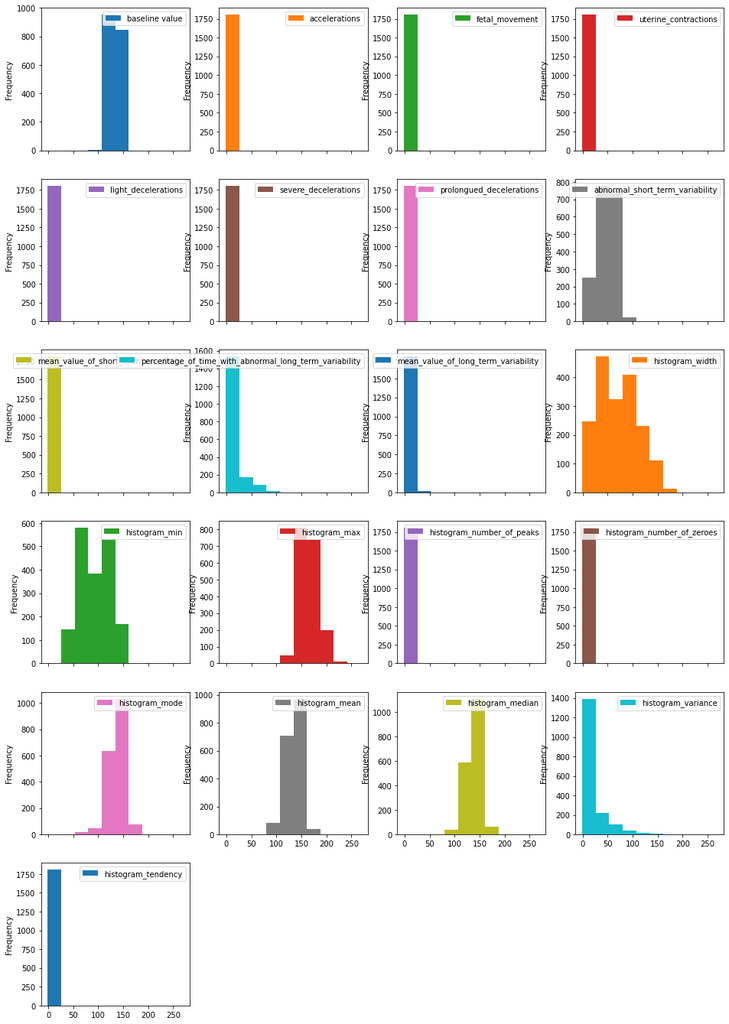

```python
# Histograms for each attribute
df_features_train.plot(kind='hist', subplots=True, layout=(display_rows, display_columns))
plt.show()
```

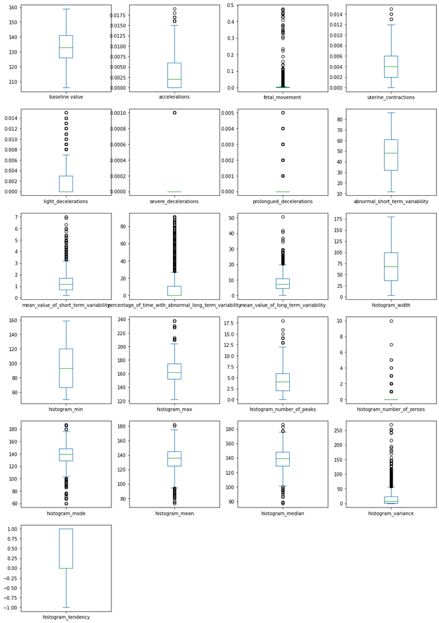

```python
# Box and Whisker plot for each attribute
df_features_train.plot(kind='box', subplots=True, layout=(display_rows, display_columns))
plt.show()
```

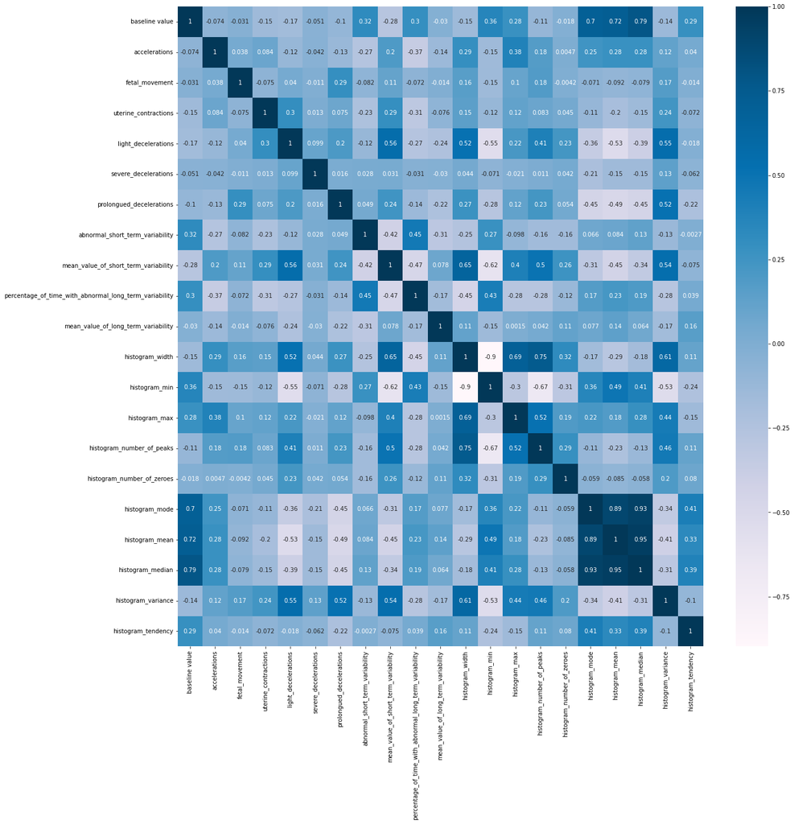

```python
# Correlation matrix
fig = plt.figure(figsize=(20, 20))
correlations = df_features_train.corr(method='pearson')
sns.heatmap(correlations, annot=True, cmap=plt.cm.PuBu)
plt.show()
```

```python
if NOTIFY_STATUS: status_notify("Task 2 - Summarize and Visualize Data completed! " + datetime.now().strftime('%a %B %d, %Y %I:%M:%S %p'))
```

## Task 3 - Pre-process Data

```python
if NOTIFY_STATUS: status_notify("Task 3 - Pre-process Data has begun! " + datetime.now().strftime('%a %B %d, %Y %I:%M:%S %p'))
```

### 3.a) Feature Scaling

```python
# Compose pipeline for the numerical and categorical features (Block #1 of 2)
numeric_columns = df_features_train.select_dtypes(include=['int64','float64']).columns
numeric_transformer = Pipeline(steps=[
    ('imputer', impute.SimpleImputer(strategy="constant", fill_value=0)),
    ('scaler', preprocessing.MinMaxScaler())
])
categorical_columns = df_features_train.select_dtypes(include=['object','bool','category']).columns
categorical_transformer = Pipeline(steps=[
    ('imputer', impute.SimpleImputer(strategy='constant', fill_value='UKNOWN')),
    ('onehot', preprocessing.OneHotEncoder(sparse=False, handle_unknown='ignore'))
])

print("Number of numerical columns:", len(numeric_columns))
print("Number of categorical columns:", len(categorical_columns))
print("Total number of columns in the feature dataframe:", df_features_train.shape[1])
```

```
Number of numerical columns: 21
Number of categorical columns: 0
Total number of columns in the feature dataframe: 21
```

```python
# Compose pipeline for the numerical and categorical features (Block #2 of 2)
preprocessor = compose.ColumnTransformer(transformers=[
    ('num', numeric_transformer, numeric_columns),
    ('cat', categorical_transformer, categorical_columns)
])

# Display the shapes of the training dataset for final inspection
array_features_train = preprocessor.fit_transform(df_features_train)
print("Transformed features from df_features_train.shape: {} to array_features_train.shape: {}".format(df_features_train.shape, array_features_train.shape))
```

```
Transformed features from df_features_train.shape: (1807, 21) to array_features_train.shape: (1807, 21)
```

### 3.b) Training Data Balancing

```python
# Not applicable for this iteration of the project
```

### 3.c) Feature Selection

```python
# Not applicable for this iteration of the project
```

### 3.d) Display the Final Datasets for Model-Building

```python
# Finalize the training dataset for the modeling activities
# array_features_train = df_features_train.to_numpy()
# array_target_train = df_target_train.ravel()
label_encoder = preprocessing.LabelEncoder()
array_target_train = keras.utils.to_categorical(label_encoder.fit_transform(df_target_train))
print("array_features_train.shape: {} array_target_train.shape: {}".format(array_features_train.shape, array_target_train.shape))
```

```
array_features_train.shape: (1807, 21) array_target_train.shape: (1807, 3)
```

```python
if NOTIFY_STATUS: status_notify("Task 3 - Pre-process Data completed! " + datetime.now().strftime('%a %B %d, %Y %I:%M:%S %p'))
```

## Task 4 - Train and Tune Models

```python
if NOTIFY_STATUS: status_notify("Task 4 - Train and Tune Models has begun! " + datetime.now().strftime('%a %B %d, %Y %I:%M:%S %p'))
```

### 4.a) Set test options and evaluation metric

```python
# Define the baseline model for benchmarking
def create_nn_model(input_param=array_features_train.shape[1], output_param=NUM_CLASSES,
                    layer1_nodes=512, layer2_nodes=512, layer3_nodes=512, layer4_nodes=512, layer5_nodes=512,
                    layer1_dropout=0.25, layer2_dropout=0.25, layer3_dropout=0.25, layer4_dropout=0, layer5_dropout=0,
                    classifier_activation=CLASSIFIER_ACTIVATION,
                    loss_param=DEFAULT_LOSS, opt_param=DEFAULT_OPTIMIZER, metrics_param=DEFAULT_METRICS):
    nn_model = keras.Sequential([
        keras.layers.Dense(layer1_nodes, input_shape=(input_param,), activation='relu'),
        keras.layers.Dropout(layer1_dropout),
        keras.layers.Dense(layer2_nodes, activation='relu'),
        keras.layers.Dropout(layer2_dropout),
        keras.layers.Dense(layer3_nodes, activation='relu'),
        keras.layers.Dropout(layer3_dropout),
        keras.layers.Dense(layer4_nodes, activation='relu'),
        keras.layers.Dropout(layer4_dropout),
        keras.layers.Dense(layer5_nodes, activation='relu'),
        keras.layers.Dropout(layer5_dropout),
        keras.layers.Dense(output_param, activation=classifier_activation)
    ])
    nn_model.compile(loss=loss_param, optimizer=opt_param, metrics=metrics_param)
    return nn_model
```

```python
# start_time_module = datetime.now()
# reset_random()
# baseline_model = create_nn_model()
# baseline_model.fit(array_features_train, array_target_train, epochs=MAX_EPOCHS, batch_size=BATCH_SIZE, verbose=1)
# print('Total time for model fitting and cross validating:', (datetime.now() - start_time_module))
```

```python
# Initialize the default model and get a baseline result
start_time_module = datetime.now()
results = list()
iteration = 0
cv = RepeatedKFold(n_splits=N_FOLDS, n_repeats=N_ITERATIONS, random_state=RNG_SEED)
for train_ix, val_ix in cv.split(array_features_train):
    feature_train, feature_validation = array_features_train[train_ix], array_features_train[val_ix]
    target_train, target_validation = array_target_train[train_ix], array_target_train[val_ix]
    reset_random()
    baseline_model = create_nn_model()
    baseline_model.fit(feature_train, target_train, epochs=MAX_EPOCHS, batch_size=BATCH_SIZE, verbose=0)
    model_metric = baseline_model.evaluate(feature_validation, target_validation, verbose=0)[1]
    iteration = iteration + 1
    print('Score from iteration %d >>> %.4f' % (iteration, model_metric))
    results.append(model_metric)
validation_score = np.mean(results)
validation_variance = np.std(results)
print('Average model score from all iterations: %.4f (%.4f)' % (validation_score, validation_variance))
print('Total time for model fitting and cross validating:', (datetime.now() - start_time_module))
```

[output not shown]

```
Score from iteration 1 >>> 0.9365
Score from iteration 2 >>> 0.9199
Score from iteration 3 >>> 0.9335
Score from iteration 4 >>> 0.9086
Score from iteration 5 >>> 0.9030
Average model score from all iterations: 0.9203 (0.0132)
Total time for model fitting and cross validating: 0:00:33.414885
```

### 4.b) Algorithm Tuning

```python
# learning_rate_reduction = ReduceLROnPlateau(monitor=TRAIN_METRIC, patience=3, verbose=1, factor=0.5, min_lr=0.00005)
# reset_random()
# tune_model = create_nn_model()
# tune_model.fit(array_features_train, array_target_train, epochs=MAX_EPOCHS, batch_size=BATCH_SIZE, callbacks=[learning_rate_reduction], verbose=1)
# tune_model.summary()
```

```python
if NOTIFY_STATUS: status_notify("Task 4 - Train and Tune Models completed! " + datetime.now().strftime('%a %B %d, %Y %I:%M:%S %p'))
```

## Task 5 - Finalize Model and Make Predictions

```python
if NOTIFY_STATUS: status_notify("Task 5 - Finalize Model and Make Predictions has begun! " + datetime.now().strftime('%a %B %d, %Y %I:%M:%S %p'))
```

### 5.a) Train the Final Model

```python
FINAL_OPTIMIZER = tf.keras.optimizers.Adam(learning_rate=0.0005)
final_model = create_nn_model(opt_param=FINAL_OPTIMIZER)
final_model.fit(array_features_train, array_target_train, epochs=MAX_EPOCHS, batch_size=BATCH_SIZE, verbose=0)
final_model.summary()
```

```
Model: "sequential_5"
_________________________________________________________________
Layer (type)                 Output Shape              Param #
=================================================================
dense_30 (Dense)             (None, 512)               11264
_________________________________________________________________
dropout_25 (Dropout)         (None, 512)               0
_________________________________________________________________
dense_31 (Dense)             (None, 512)               262656
_________________________________________________________________
dropout_26 (Dropout)         (None, 512)               0
_________________________________________________________________
dense_32 (Dense)             (None, 512)               262656
_________________________________________________________________
dropout_27 (Dropout)         (None, 512)               0
_________________________________________________________________
dense_33 (Dense)             (None, 512)               262656
_________________________________________________________________
dropout_28 (Dropout)         (None, 512)               0
_________________________________________________________________
dense_34 (Dense)             (None, 512)               262656
_________________________________________________________________
dropout_29 (Dropout)         (None, 512)               0
_________________________________________________________________
dense_35 (Dense)             (None, 3)                 1539
=================================================================
Total params: 1,063,427
Trainable params: 1,063,427
Non-trainable params: 0
_________________________________________________________________
```

### 5.b) Load Test Dataset and Make Predictions

```python
# Finalize the test dataset for the testing activities
array_features_test = preprocessor.transform(df_features_test)
array_target_test = keras.utils.to_categorical(label_encoder.transform(df_target_test))
print("array_features_test.shape: {} array_target_test.shape: {}".format(array_features_test.shape, array_target_test.shape))
```

```
array_features_test.shape: (319, 21) array_target_test.shape: (319, 3)
```

```python
# Make batched predictions
test_predictions = label_encoder.inverse_transform(np.argmax(final_model.predict(array_features_test), axis=-1))
print(test_predictions)
```

```
[3 1 1 1 1 1 1 1 3 2 1 1 1 1 1 1 1 1 1 1 3 1 1 1 1 3 1 1 1 1 1 1 1 1 1 1 1
 3 3 2 1 1 1 1 1 1 1 2 1 1 3 1 3 1 1 1 1 1 1 1 1 1 1 1 1 1 1 1 1 1 1 1 1 1
 1 1 1 1 1 2 1 1 1 1 1 1 1 1 1 3 1 1 2 3 3 2 2 1 1 1 1 1 1 1 1 1 1 1 1 1 1
 3 1 1 3 1 1 1 1 1 1 3 1 1 1 1 1 1 1 1 1 1 1 1 1 1 1 2 2 1 1 1 1 1 1 2 1 1
 3 1 1 1 1 1 1 1 1 1 2 2 1 1 1 1 1 1 1 1 1 2 2 1 1 1 1 1 1 2 1 1 1 1 1 1 1
 1 1 1 1 3 1 2 1 1 1 1 1 1 1 1 1 2 1 2 1 3 1 1 1 1 1 2 3 1 1 1 1 1 1 1 1 1
 2 1 1 3 2 1 3 1 1 1 1 1 1 1 1 1 1 1 3 1 1 1 3 1 1 2 1 1 1 1 1 3 1 2 1 1 1
 1 1 1 1 1 1 1 1 1 1 1 1 1 1 2 2 1 1 2 1 1 2 2 1 1 1 1 1 1 1 1 1 1 1 1 1 1
 2 1 3 1 1 1 3 1 1 1 1 3 1 1 1 1 2 1 1 1 1 1 1]
```

```python
array_target_test = df_target_test.ravel()
print('Accuracy Score:', accuracy_score(array_target_test, test_predictions), '\n')
print(confusion_matrix(array_target_test, test_predictions), '\n')
print(classification_report(array_target_test, test_predictions))
```

```
Accuracy Score: 0.9184952978056427

[[245   2   1]
 [ 17  25   2]
 [  1   3  23]]

              precision    recall  f1-score   support

           1       0.93      0.99      0.96       248
           2       0.83      0.57      0.68        44
           3       0.88      0.85      0.87        27

    accuracy                           0.92       319
   macro avg       0.88      0.80      0.83       319
weighted avg       0.91      0.92      0.91       319
```

```python
if NOTIFY_STATUS: status_notify("Task 5 - Finalize Model and Make Predictions completed! " + datetime.now().strftime('%a %B %d, %Y %I:%M:%S %p'))
```

```python
print ('Total time for the script:',(datetime.now() - START_TIME_SCRIPT))
```

```
Total time for the script: 0:00:47.292994
```